# Homework 10

# Submission Instructions

- Submit responses in a .ipynb file.
- For calculation questions:
  - Include R code used.
  - Ensure all code has been executed to display output.
  - Round *answers* to 3-5 decimal places if necessary.
  - Avoid displaying unnecessary R outputs.
  - Support conclusions with plots when checking assumptions.
  - Assume $\alpha = 0.05$ unless stated otherwise.
  - Two-sided hypothesis tests require two-sided confidence intervals.
  - One-sided hypothesis tests require one-sided confidence intervals.

# *One-Way ANOVA Questions*

# Question 1

The data contained in **“smokers.csv”** reports the findings of Spilich, June, and Renner (1992) who asked nonsmokers (NS), smokers who had delayed smoking for three hours (DS), and smokers who were actively smoking (AS) to perform a pattern recognition task in which they had to locate a target on a screen. The dependent variable was latency (in seconds).

Plot the means and 95% confidence intervals of the **smokers.csv** data.

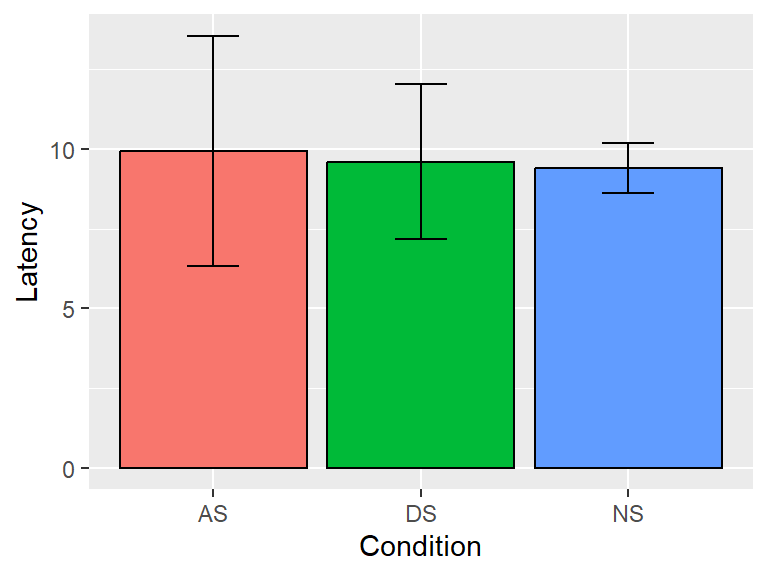

```r
# Load Data
smoke <- read_csv("../Data/smokers.csv")

# Get Aggregated Plot Data
plot_data <- smoke |>
  group_by(Condition) |>
  summarise(
    n = length(Latency),
    m = mean(Latency),
    df = (n - 1),
    alpha = 0.05,
    t_crit = abs(qt(alpha/2, df = df)),
    se = sd(Latency) / sqrt(n),
    moe = t_crit * se
  )

# Plot
ggplot(plot_data, aes(x = Condition, y = m, fill = Condition)) +
  geom_bar(stat = "identity", colour = "black") +
  geom_errorbar(
    aes(ymin = m - moe, ymax = m + moe),
    width = .25
  ) +
  ylab("Latency") +
  theme(legend.position = "none")
```

# Question 2

Looking at the plot, what is a potential concern for the **smokers.csv** data?

- It might have heterogeneous variances.

# Question 3

Without using the `lm()` or `aov()` function, compute an omnibus F-test. Is there support for the hypothesis that smoking has an effect on performance? Report the …

- F-statistic
- Degrees of freedom
- P-value.

```r
# Basic Stats
N <- nrow(smoke)
m_grand <- mean(smoke$Latency)
```

```r
#TOTAL SUM OF SQUARES - SST
SST <- sum((smoke$Latency - m_grand)^2)
df_t <- N - 1
```

```r
#MODEL SUM OF SQUARES - SSM
#Getting the group means
grp_means <- smoke |>
  group_by(Condition) |>
  summarise(
    n = length(Latency),
    m = mean(Latency)
  )

SSM <- sum(grp_means$n * ((grp_means$m - m_grand)^2))
df_m <- 3 - 1
```

```r
#RESIDUAL SUM OF SQUARES - SSR
SSR <- SST - SSM
df_r <- df_t - df_m
```

```r
#MEAN SQUARES
MS_m <- SSM / df_m
MS_r <- SSR / df_r
```

```r
#F-statistic
F_stat <- MS_m / MS_r

#P-value
p <- pf(F_stat, df1 = df_m, df2 = df_r, lower.tail = FALSE)
```

```
## [1] "F = 0.051"
## [1] "df1 = 2, df2 = 42"
## [1] "p = 0.95"
```

There is no clear support for the hypothesis that smoking has an effect on mean performance.

- *Note: There is a caveat to this that should be mentioned. While the means don’t significantly differ, the variability seems to (at least based on the graph). So it’s likely that smoking does have an effect on performance: it makes performance more variable. Unfortunately a standard ANOVA does not capture this aspect of the results.*

# Question 4

Report an effect size in terms of $\omega^2$ for the test you ran in the previous question. You should obtain a negative result. What do you think this means in plain English?

```r
omega_sq <- (SSM - df_m * MS_r)/(SSM + SSR + MS_r)
omega_sq
```

```
## [1] -0.0440279
```

- It means that there is no observed effect. $\omega^2$ represents the proportion of variance accounted for by the model (i.e., $\omega^2$ is a version of $R^2$), thus it technically shouldn’t exceed 0 and 1. However, because it is an unbiased estimate, it ends up with the ability to do this. Consequently, when $\omega^2$ is negative, you can treat it as $\omega^2 = 0$.
  - Note to marker, just give full marks for reporting $\omega^2$ correctly and attempting an answer.

# Question 5

Run an ANOVA with planned contrasts that 1) compares the combined effect of the active smokers and delayed smokers to the non-smokers and 2) compares the active smokers with the delayed smokers.

Report the test statistic, degrees of freedom, and p-value for those two comparisons. You ARE allowed to use the functions `lm()` and `aov()`.

```r
smoke$Condition <- factor(smoke$Condition)
levels(smoke$Condition)
```

```
## [1] "AS" "DS" "NS"
```

```r
cont1 <- c(1, 1, -2)
cont2 <- c(1, -1, 0)

contrasts(smoke$Condition) <- cbind(cont1, cont2)

model <- lm(Latency ~ Condition, data = smoke)
mod_dum <- summary(model)
# mod_dum
```

```
## [1] "(AS + DS) vs NS: t = 0.251, df = 42, p = 0.803"
```

```
## [1] "AS vs DS: t = 0.198, df = 42, p = 0.844"
```

# Question 6

Report an effect size in terms of $R$ (the correlation coefficient) for each of the contrasts you conducted in the previous question.

```r
#Cont 1: (AS + DS) vs NS
df_cont1 <- N - 2 - 1
t_cont1 <- mod_dum$coefficients[8]

r_cont1 <- sqrt((t_cont1^2) / (t_cont1^2 + df_cont1))
```

```r
#Cont 2: AS vs DS
df_cont2 <- N - 2 - 1
t_cont2 <- mod_dum$coefficients[9]

r_cont2 <- sqrt((t_cont2^2) / (t_cont2^2 + df_cont2))
```

```
## [1] "(AS + DS) vs NS: R = 0.039"
```

```
## [1] "AS vs DS: R = 0.031"
```

# Question 7

The confidence intervals around the mean suggested that there might be heterogeneous variances. Run a statistical test to assess the assumption of homogeneity of variances. Display the results of the test. What does it conclude and what is wrong with using tests like this to check your assumptions?

```r
library(car)
leveneTest(smoke$Latency, smoke$Condition, center = median)
```

```
## Levene's Test for Homogeneity of Variance (center = median)
##       Df F value   Pr(>F)
## group  2  5.6205 0.006872 **
##       42
## ---
## Signif. codes:  0 '***' 0.001 '**' 0.01 '*' 0.05 '.' 0.1 ' ' 1
```

The test rejects the hypothesis that the group variances are equal. If the statistical power is too low, it will not find true differences, if the statistical power is too high, it will find pointlessly small differences.

# Question 8

For the **“smokers.csv”** data, assume there is a true effect in the population, but it is very small; $f = 0.05$. What is the **total** sample size that would be needed to detect this effect if you wanted the ANOVA to have a power level of 0.85? Round to the nearest person.

```r
library(pwr)
result <- pwr.anova.test(k = 3, f = 0.05, sig.level = 0.05, power = 0.85)
round(result$n) * 3
```

```
## [1] 4371
```

# Question 9

Recall that there is a version of the t-test called a “Welch’s t-test” that is robust to unequal variances. The Welch procedure can actually be extended to One-Way ANOVAs using the function `oneway.test()`.

Use your excellent sleuthing skills to figure out how to use this function and display its results (Omnibus F-stat, degrees of freedom, and p-value) for a One-Way analysis of variance that doesn’t assume equal variances on the **“smokers.csv”** data. Does your interpretation of this ANOVA change from the first one you ran?

```r
oneway.test(Latency ~ Condition, data = smoke, var.equal = FALSE)
```

```
##
##  One-way analysis of means (not assuming equal variances)
##
## data:  Latency and Condition
## F = 0.057131, num df = 2.000, denom df = 21.113, p-value = 0.9446
```

The interpretation does not change. Smoking does not seem to have an effect on the mean performance.

# *Two-Way ANOVA Questions*

The datafile **“memory.csv”** contains data from a study looking at the effects of memory on the learning of a foreign vocabulary.

Most of you have probably read that a good strategy for memorizing words in a foreign language is to think of mnemonic keywords. For example, in Tagalog (the official language of the Philippines), the word for eyeglasses is “salamin”. That word sounds much like the English word “salmon,” so a possible strategy would be to imagine a picture of a salmon wearing glasses. This type of encoding strategy has been recommended for years, and people who try it generally report good immediate recall of foreign vocabulary. This fits nicely with dual-coding theories, in which the word is viewed as being stored both lexically and visually. However, the studies that have looked at this phenomenon have generally asked the same participants to recall items at several different times. Since each recall session means an additional practice session, practice and time effects are confounded. To get around this problem, Thomas and Wang (1996) used different participants at the two recall intervals. Data with very nearly the same means and variances as theirs are presented below.

Thomas and Wang (1996) ran a study in which they divided participants into one of three “Strategy” groups, and then tested them at one of two times (5 minutes or 2 days). The strategies were

- **Keyword-Generated**: Participants generated their own keywords to help them to remember 24 Tagalog words.
- **Keyword-Provided:** The experimenters provided the keywords to help them to remember 24 Tagalog words.
- **Rote Learning:** Participants were simply instructed to memorize the meaning of the Tagalog words.

The dependent variable was the number of English words recalled at either 5 minutes or 2 days. Use the **memory.csv** data to answer the questions below.

- Thomas, M. H., & Wang, A. Y. (1996). Learning by the keyword mnemonic: Looking for long-term benefits. *Journal of Experimental Psychology: Applied*, *2*(4), 330–342. https://doi.org/10.1037/1076-898X.2.4.330

# Question 10

Assume you are going to run a Two-Way independent ANOVA on the **“memory.csv”** data. Answer the question ‘is the data balanced?’

```r
library(tidyverse)

# Load Data
mem <- read_csv("../Data/memory.csv")

# Create Table to see sample size per level
table(mem$Strategy, mem$Delay)
```

```
##
##             2d 5m
##   Generated 13 13
##   Provided  13 13
##   Rote      13 13
```

The data is balanced.

# Question 11

Without doing any analyses, what kinds of results do you expect to see for the main effects? i.e., what are your predictions?

> Recall will probably be best when subjects generate their own words and worst in the rote learning. There will probably also be better recall for the short delay than the long delay.
- *Note for marker:* Provide full marks for any reasonable prediction.

# Question 12

Plot the means and 95% confidence intervals of this data. Does it look like there is an interaction?

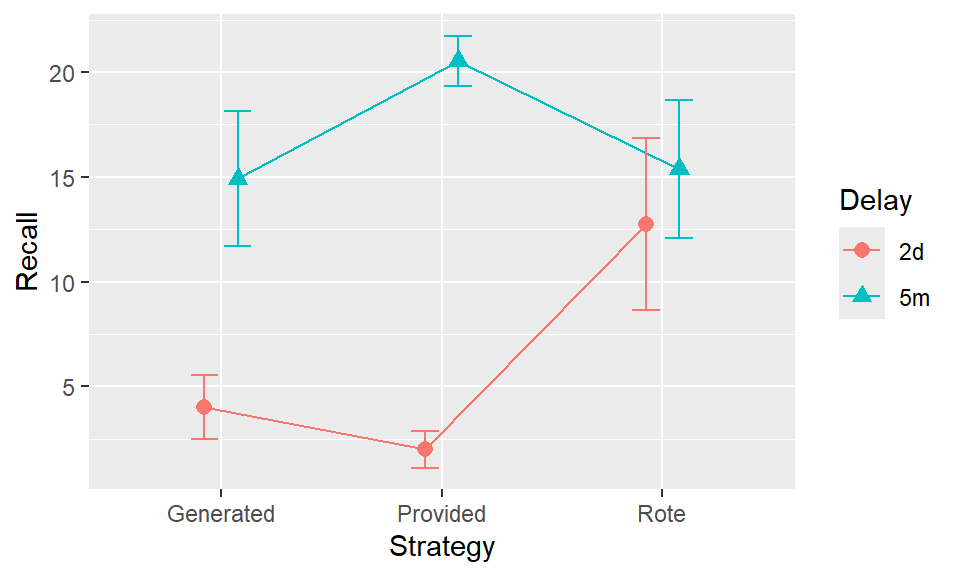

```r
# Get Plot Information
plot_data <- mem |>
  group_by(Strategy, Delay) |>
  summarise(
    n = length(Recall),
    m = mean(Recall),
    alpha = 0.05,
    t_crit = abs(qt(alpha / 2, df = n - 1)),
    se = sd(Recall) / sqrt(n),
    moe = t_crit * se
  )

# Plot
ggplot(
  plot_data,
  aes(
    x = Strategy, y = m,
    group = Delay,
    colour = Delay,
    shape = Delay
  )
) +
  geom_line(position = position_dodge(width = 0.3)) +
  geom_point(size = 2.5, position = position_dodge(width = 0.3)) +
  geom_errorbar(
    aes(ymin = m - moe, ymax = m + moe),
    width = .25,
    position = position_dodge(width = 0.3)
  ) +
  ylab("Recall")
```

The lines are not parallel, so there is probably an interaction.

##### Note: if you put Delay on the x-axis instead, and group by Strategy, you should still arrive at the same conclusion (non-parallel lines).

# Question 13

Without using the functions `lm()` , `aov()`, or `anova()`, calculate the total sum of squares and its degrees of freedom.

```r
SST <- sum((mem$Recall - mean(mem$Recall))^2)

N <- nrow(mem)
df_T <- N - 1
```

```
## [1] "SST = 4736.679"
```

```
## [1] "df = 77"
```

# Question 14

Without using the functions `lm()` , `aov()`, or `anova()`, calculate the model’s sum of squares and the model’s degrees of freedom.

```r
# Note the dataframe we made for the plot has everything we need for this calculation.
SSM <- sum(plot_data$n * (plot_data$m - mean(mem$Recall))^2)
df_M <- nrow(plot_data) - 1
```

```
## [1] "SSM = 3335.141"
```

```
## [1] "df = 5"
```

# Question 15

Without using the functions `lm()` , `aov()`, or `anova()`, calculate the sum of squares for a main effect of “Strategy” and its degrees of freedom.

```r
# SSA
# Getting means and sample sizes for Strategy
A <- mem |>
  group_by(Strategy) |>
  summarise(
    n = length(Recall),
    m = mean(Recall)
  )

# Sum of Squares
SSA <- sum(A$n * (A$m - mean(mem$Recall))^2)

# Degrees of Freedom
df_A <- nrow(A) - 1
```

```
## [1] "SSA = 281.256"
```

```
## [1] "df = 2"
```

# Question 16

Without using the functions `lm()` , `aov()`, or `anova()`, calculate the sum of squares for a main effect of “Delay” and it’s degrees of freedom.

```r
# SSA
# Getting means and sample sizes for Delay
B <- mem |>
  group_by(Delay) |>
  summarise(
    n = length(Recall),
    m = mean(Recall)
  )

# Sum of Squares
SSB <- sum(B$n * (B$m - mean(mem$Recall))^2)

# Degrees of Freedom
df_B <- nrow(B) - 1
```

```
## [1] "SSB = 2229.346"
```

```
## [1] "df = 1"
```

# Question 17

Without using the functions `lm()` , `aov()`, or `anova()`, calculate the sum of squares for a possible interaction and it’s degrees of freedom.

```r
# SSI
SSI <- SSM - SSA - SSB
df_I <- df_A * df_B
```

```
## [1] "SSI = 824.538"
```

```
## [1] "df = 2"
```

# Question 18

Without using the functions `lm()` , `aov()`, or `anova()`, calculate the sum of squares for the residuals/error and it’s degrees of freedom.

```r
# SSR
SSR <- SST - SSM
df_R <- df_T - df_M
```

```
## [1] "SSR = 1401.538"
```

```
## [1] "df = 72"
```

# Question 19

Without using the functions `lm()` , `aov()`, or `anova()`, calculate the mean squares for the effect of Strategy, Delay, the interaction between Strategy and Delay, and the mean square error/residuals.

```r
# MS
MS_A <- SSA / df_A
MS_B <- SSB / df_B
MS_I <- SSI / df_I
MS_R <- SSR / df_R
```

```
## [1] "Strategy: MS_A = 140.628"
```

```
## [1] "Delay: MS_B = 2229.346"
```

```
## [1] "Interaction: MS_I = 412.269"
```

```
## [1] "Residuals: MS_R = 19.466"
```

# Question 20

Without using the functions `lm()` , `aov()`, or `anova()`, calculate the F-ratios for each main effect and the interaction. Also report the associated degrees of freedom and p-value.

```r
# Strategy
F_A <- MS_A / MS_R
p_A <- pf(F_A, df1 = df_A, df2 = df_R, lower.tail = FALSE)

# Delay
F_B <- MS_B / MS_R
p_B <- pf(F_B, df1 = df_B, df2 = df_R, lower.tail = FALSE)

# Interaction
F_I <- MS_I / MS_R
p_I <- pf(F_I, df1 = df_I, df2 = df_R, lower.tail = FALSE)
```

```
## [1] "A: Strategy: F = 7.224, df1 = 2, df2 = 72, p = 0.001"
```

```
## [1] "B: Delay: F = 114.526, df1 = 1, df2 = 72, p = 0"
```

```
## [1] "Interaction: F = 21.179, df1 = 2, df2 = 72, p = 0"
```

# Question 21

Use one of R’s “cheat codes” (i.e., functions) to quickly check and see if your results are correct. Make sure your output displays the degrees of freedom, sum of squares, F-Ratios, and p-values.

```r
# Factor the columns
mem$Strategy <- factor(mem$Strategy)
mem$Delay <- factor(mem$Delay)

# Generate output
model <- lm(Recall ~ Strategy + Delay + Strategy:Delay,
  data = mem
)

print(anova(model))
```

```
## Analysis of Variance Table
##
## Response: Recall
##                Df  Sum Sq Mean Sq  F value    Pr(>F)
## Strategy        2  281.26  140.63   7.2244  0.001382 **
## Delay           1 2229.35 2229.35 114.5262 < 2.2e-16 ***
## Strategy:Delay  2  824.54  412.27  21.1791 5.839e-08 ***
## Residuals      72 1401.54   19.47
## ---
## Signif. codes:  0 '***' 0.001 '**' 0.01 '*' 0.05 '.' 0.1 ' ' 1
```

```r
# note that you could also do ....
# summary(aov(Recall ~ Strategy + Delay + Strategy:Delay, data = mem))
```

# Question 22

In plain English, what do the results of the ANOVA you ran tell you?

- Both strategy and delay significantly impact the recall but there is an interaction present. i.e., strategy’s impact varies depending on the delay.

# Question 23

Assume the **“memory.csv”** data is unbalanced and the researchers **don’t** want to violate the principle of marginality. Re-run question 21 in a way that does not violate this principle.

```r
library(car)
print(Anova(model, type = "II"))
```

```
## Anova Table (Type II tests)
##
## Response: Recall
##                 Sum Sq Df  F value    Pr(>F)
## Strategy        281.26  2   7.2244  0.001382 **
## Delay          2229.35  1 114.5262 < 2.2e-16 ***
## Strategy:Delay  824.54  2  21.1791 5.839e-08 ***
## Residuals      1401.54 72
## ---
## Signif. codes:  0 '***' 0.001 '**' 0.01 '*' 0.05 '.' 0.1 ' ' 1
```

# Question 24

Assume the **“memory.csv”** data is unbalanced and that you would happily jump off a bridge if most researchers told you to do it. Re-run question 21’s analyses using Type-III sum of squares.

Note: Your result here should be identical to the previous two if you have done it correctly.

**Note: For this to work you need to first set orthogonal contrasts. It doesn’t matter what the comparisons are, as long they are orthogonal.**

```r
# Set some orthogonal contrasts
contrasts(mem$Delay) <- c(-1, 1)

cont1 <- c(1, 1, -2)
cont2 <- c(1, -1, 0)
contrasts(mem$Strategy) <- cbind(cont1, cont2)

# Generate output
model <- lm(Recall ~ Strategy + Delay + Strategy:Delay,
  data = mem
)

# Display main effects and interactions
print(Anova(model, type = "III"))
```

```
## Anova Table (Type III tests)
##
## Response: Recall
##                 Sum Sq Df  F value    Pr(>F)
## (Intercept)    10500.3  1 539.4237 < 2.2e-16 ***
## Strategy         281.3  2   7.2244  0.001382 **
## Delay           2229.3  1 114.5262 < 2.2e-16 ***
## Strategy:Delay   824.5  2  21.1791 5.839e-08 ***
## Residuals       1401.5 72
## ---
## Signif. codes:  0 '***' 0.001 '**' 0.01 '*' 0.05 '.' 0.1 ' ' 1
```

# *Note about remaining topics*

Questions on the remaining topics—Factorial ANOVA Contrasts and Chi-Squared Tests—will be posted in a separate homework document on our course page next week. These questions will not be graded, but I strongly encourage you to complete them, as they cover material that will appear on the final exam.